# **Fantasy Sports Clustering Analysis**

## **Context**

Fantasy sports are online gaming platforms where participants draft and manage virtual teams of real professional sports players. Based on the performance of the players in the real world, players are allotted points in the fantasy sports platform every match. The objective is to create the best possible team with a fixed budget to score maximum fantasy points, and users compete against each other over an entire sports league or season. Some of these fantasy sports require actual financial investments for participation, with chances of winning monetary rewards as well as free matchday tickets on a periodic basis.

The fantasy sports market has seen tremendous growth over the past few years, with a valuation of \$18.6 billion in 2019. The soccer (globally - football) segment led in terms of market share in 2019, with over 8 million participants worldwide, and is expected to retain its dominance over the next couple of years. Digitalization is one of the primary factors driving the growth of the fantasy sports market as it allows participants the opportunity to compete on a global level and test their skills. With an increase in smartphone usage and availability of fantasy sports apps, this market is expected to witness a global surge and reach a \$48.6 billion valuation by 2027.

## **Objective**

OnSports is a fantasy sports platform that has fantasy leagues for many different sports and has witnessed an increasing number of participants globally over the past 5 years. For each player, a price is set at the start, and the price keeps changing over time based on the performance of the players in the real world. With the new English Premier League season about to start, they have collected data from the past season and want to analyze it to determine the price of each player for the start of the new season. OnSports have hired you as a data scientist and asked you to conduct a cluster analysis to identify players of different potentials based on previous season performances. This will help them understand the patterns in player performances and fantasy returns and decide the exact price to be set for each player for the upcoming football season.

## **Data Description**

- **Player_Name:** Name of the player.
- **Club:** Club in which the player plays.
- **Position:** Position in which the player plays.
- **Goals_Scored:** Number of goals scored by the player in the previous season.
- **Assists:** Number of passes made by the player leading to goals in the previous season.
- **Total_Points:** Total number of fantasy points scored by the player in the previous season.
- **Minutes:** Number of minutes played by the player in the previous season.
- **Goals_Conceded:** Number of goals conceded by the player in the previous season.
- **Creativity:** A score, computed using a range of stats, that assesses player performance in terms of producing goalscoring opportunities for other players.
- **Influence:** A score, computed using a range of stats, that evaluates a player's impact on a match, taking into account actions that could directly or indirectly affect the match outcome.
- **Threat:** A score, computed using a range of stats, that gauges players who are most likely to score goals.
- **Bonus:** Total bonus points received. The three best performing players in each match receive additional bonus points based on a score computed using a range of stats. 3 points are awarded to the highest scoring player, 2 to the second best, and 1 to the third.
- **Clean_Sheets:** Number of matches without conceding a goal in the previous season.

## Import Libraries

```python
import pandas as pd
import numpy as np

import seaborn as sns
import matplotlib.pyplot as plt

import warnings
warnings.filterwarnings('ignore')

from sklearn.preprocessing import StandardScaler
from sklearn.decomposition import PCA

from sklearn.cluster import KMeans
from sklearn.metrics import silhouette_score
from sklearn.mixture import GaussianMixture
from sklearn_extra.cluster import KMedoids
from sklearn.cluster import DBSCAN
from sklearn.cluster import AgglomerativeClustering

from scipy.cluster.hierarchy import dendrogram, linkage, cophenet
from scipy.spatial.distance import cdist, pdist
```

## Import Dataset and analysis it

```python
df_fancy = pd.read_csv('fpl_data.csv')
df_fancy.head()
```

|  | Player_Name | Club | Position | Goals_Scored | Assists | Total_Points | Minutes | Goals_Conceded | Creativity | Influence | Threat | Bonus | Clean_Sheets |
| --- | --- | --- | --- | --- | --- | --- | --- | --- | --- | --- | --- | --- | --- |
| 0 | Alex Runnarsson | Arsenal | Goalkeeper | 0 | 0 | 1 | 15 | 0 | 0.0 | 16.6 | 0 | 0 | 0 |
| 1 | Alexandre Lacazette | Arsenal | Forward | 13 | 3 | 129 | 1916 | 21 | 307.4 | 602.4 | 797 | 21 | 7 |
| 2 | Bernd Leno | Arsenal | Goalkeeper | 0 | 0 | 131 | 3131 | 37 | 0.0 | 702.2 | 2 | 11 | 11 |
| 3 | Bukayo Saka | Arsenal | Midfielder | 5 | 5 | 114 | 2554 | 31 | 650.6 | 493.0 | 984 | 8 | 8 |
| 4 | Calum Chambers | Arsenal | Defender | 0 | 3 | 36 | 751 | 10 | 169.4 | 171.8 | 77 | 3 | 2 |

```python
df_fancy.info()
```

```
<class 'pandas.core.frame.DataFrame'>
RangeIndex: 476 entries, 0 to 475
Data columns (total 13 columns):
 #   Column          Non-Null Count  Dtype
---  ------          --------------  -----
 0   Player_Name     476 non-null    object
 1   Club            476 non-null    object
 2   Position        476 non-null    object
 3   Goals_Scored    476 non-null    int64
 4   Assists         476 non-null    int64
 5   Total_Points    476 non-null    int64
 6   Minutes         476 non-null    int64
 7   Goals_Conceded  476 non-null    int64
 8   Creativity      476 non-null    float64
 9   Influence       476 non-null    float64
 10  Threat          476 non-null    int64
 11  Bonus           476 non-null    int64
 12  Clean_Sheets    476 non-null    int64
dtypes: float64(2), int64(8), object(3)
memory usage: 48.5+ KB
```

- 476 player are in this dataset and it includes 13 columns.
- No data is missing.
- 10 of the features are numerical while 3 features, player_name, club and position are categorical format.

```python
df_fancy['Player_Name'].nunique()
```

```
476
```

```python
df_fancy['Club'].nunique()
```

```
17
```

```python
df_fancy['Club'].value_counts()
```

```
Arsenal                     30
Crystal Palace              30
Leeds United                29
West Ham United             29
Tottenham Hotspurs          29
Newcastle United            29
Leicester City              29
Manchester United           28
Chelsea                     28
Brighton and Hove Albion    28
Everton                     27
Liverpool                   27
Manchester City             27
Southampton                 27
Burnley                     27
Aston Villa                 26
Wolverhampton Wanderers     26
Name: Club, dtype: int64
```

```python
df_fancy['Position'].nunique()
```

```
4
```

```python
df_fancy['Position'].value_counts()
```

```
Midfielder    195
Defender      172
Forward        64
Goalkeeper     45
Name: Position, dtype: int64
```

- All the players names are unique so this columns doesn't have any information and can be eliminated.
- They are 17 unique clubs in this game and each came up around 26 to 30 times
- There are 4 unique positions. Which can be important and we can assign number to it. 195 Midfielder, 172 Defender, 64 Forward and 45 GoalKeeper.

```python
df_fancy.duplicated().sum()
```

```
0
```

```python
df_fancy.isnull().sum()
```

```
Player_Name       0
Club              0
Position          0
Goals_Scored      0
Assists           0
Total_Points      0
Minutes           0
Goals_Conceded    0
Creativity        0
Influence         0
Threat            0
Bonus             0
Clean_Sheets      0
dtype: int64
```

- No duplicate or null in our dataset.

```python
df_fancy.describe(include='all').T
```

|  | count | unique | top | freq | mean | std | min | 25% | 50% | 75% | max |
| --- | --- | --- | --- | --- | --- | --- | --- | --- | --- | --- | --- |
| Player_Name | 476 | 476 | Alex Runnarsson | 1 | NaN | NaN | NaN | NaN | NaN | NaN | NaN |
| Club | 476 | 17 | Arsenal | 30 | NaN | NaN | NaN | NaN | NaN | NaN | NaN |
| Position | 476 | 4 | Midfielder | 195 | NaN | NaN | NaN | NaN | NaN | NaN | NaN |
| Goals_Scored | 476.0 | NaN | NaN | NaN | 1.907563 | 3.455562 | 0.0 | 0.0 | 0.5 | 2.0 | 23.0 |
| Assists | 476.0 | NaN | NaN | NaN | 1.752101 | 2.708563 | 0.0 | 0.0 | 0.0 | 2.0 | 14.0 |
| Total_Points | 476.0 | NaN | NaN | NaN | 58.516807 | 51.293559 | 0.0 | 10.0 | 48.0 | 94.25 | 244.0 |
| Minutes | 476.0 | NaN | NaN | NaN | 1336.909664 | 1073.773995 | 0.0 | 268.75 | 1269.5 | 2256.25 | 3420.0 |
| Goals_Conceded | 476.0 | NaN | NaN | NaN | 19.157563 | 15.946171 | 0.0 | 4.0 | 18.0 | 31.0 | 68.0 |
| Creativity | 476.0 | NaN | NaN | NaN | 195.97605 | 251.478541 | 0.0 | 8.3 | 96.95 | 296.95 | 1414.9 |
| Influence | 476.0 | NaN | NaN | NaN | 294.617647 | 267.779681 | 0.0 | 46.5 | 233.1 | 499.5 | 1318.2 |
| Threat | 476.0 | NaN | NaN | NaN | 224.962185 | 318.240377 | 0.0 | 5.75 | 104.5 | 298.25 | 1980.0 |
| Bonus | 476.0 | NaN | NaN | NaN | 4.718487 | 6.252625 | 0.0 | 0.0 | 2.0 | 7.0 | 40.0 |
| Clean_Sheets | 476.0 | NaN | NaN | NaN | 4.745798 | 4.394312 | 0.0 | 0.0 | 4.0 | 8.0 | 19.0 |

- On average players scored ~2 goals. High StD incidates that this data is highly right-Skewed. 50% of the player scored zero or no goal.
- On average players played 1337 min in the game.
- On average 58 point scored by the player in the last season.

## Data Visualization - Univariate data

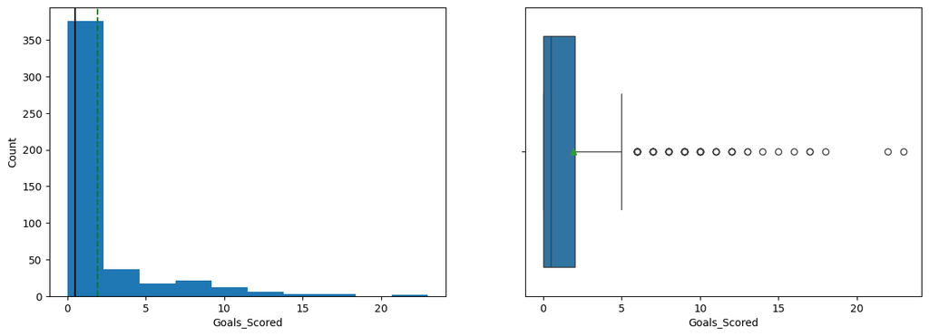

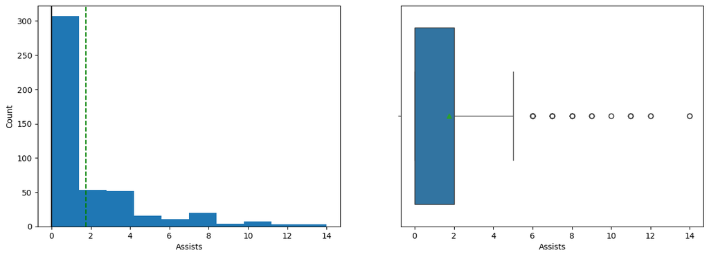

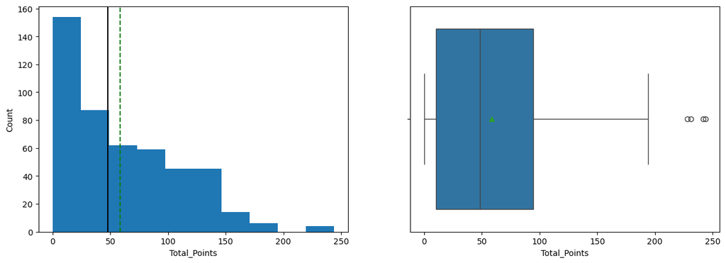

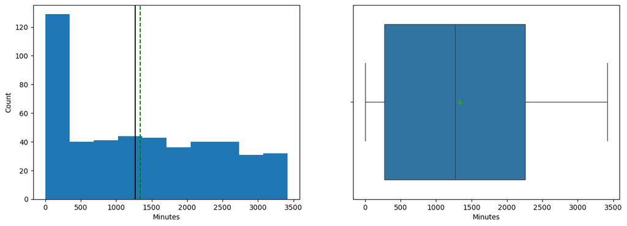

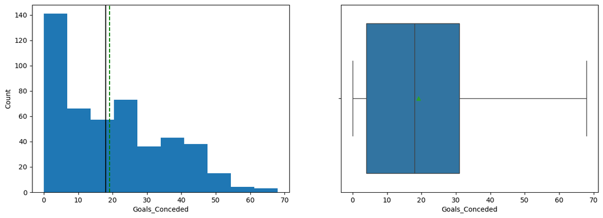

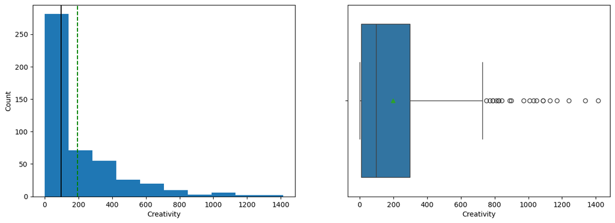

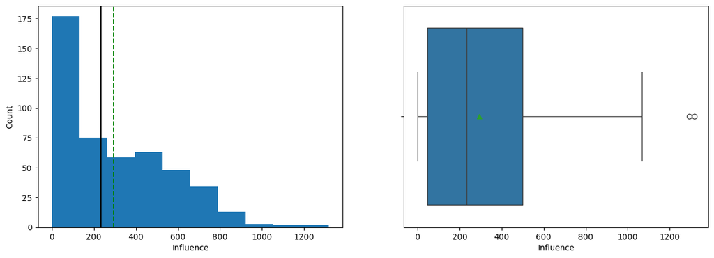

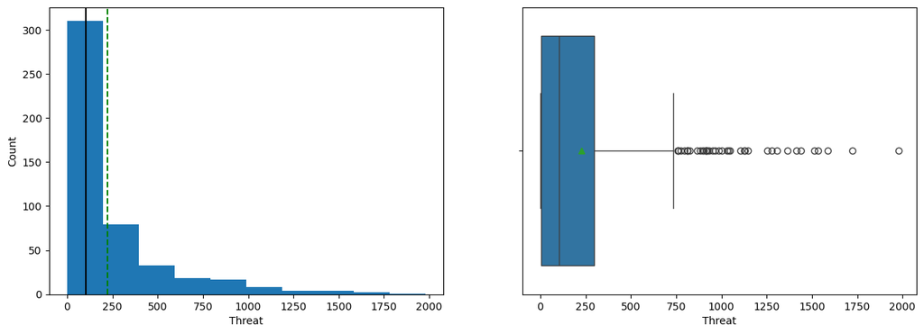

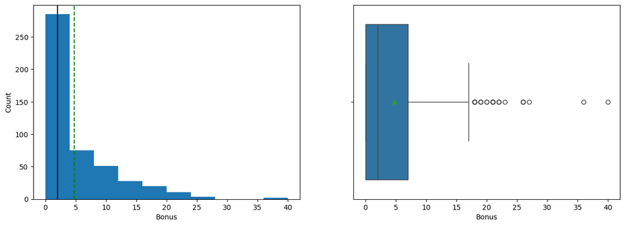

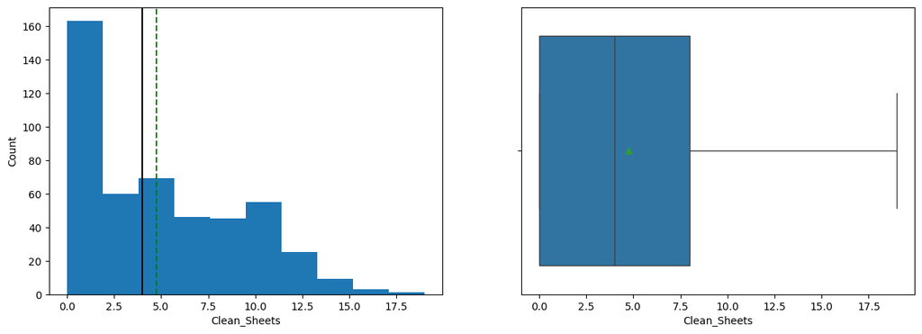

```python
Num_columns = ['Goals_Scored', 'Assists', 'Total_Points', 'Minutes', 'Goals_Conceded', 'Creativity', 'Influence', 'Threat', 'Bonus', 'Clean_Sheets']
for col in Num_columns:
    plt.figure(figsize=(15,5))
    x = plt.subplot(1,2,1)
    plt.hist(data=df_fancy, x=col)
    plt.ylabel('Count')
    plt.xlabel(col)
    x.axvline(df_fancy[col].mean(), color = 'green', linestyle='--')
    x.axvline(df_fancy[col].median(), color = 'black')
    x2 = plt.subplot(1,2,2)
    sns.boxplot(data=df_fancy, x=col, showmeans =True)
    plt.show()
```

- These data points are right skewed:
  - Goal Scored with few player scored more than 15 goals.
  - Assists with few players assists more than 8 goals.
  - Total_Points 50% of players scored more than 50 fantacy points. Many players scored zero fanct points and outlier with lot's of fancy points.
  - Minutes with 25% players played less than ~268 min in the season. There are players that didn't play at all.
  - Goals_Conceded with 50% of player conducted less than 20 goals.
  - Creativity and few players has above 500 score on creativity.
  - Influence and few players has influence above 800 score.
  - Threat with few players score above 500.
  - Bonus with few players recieved more than 20 bouns fantcy points in the last season.
  - Clean_Sheets with 50% of the player have 4 or less clean sheets.

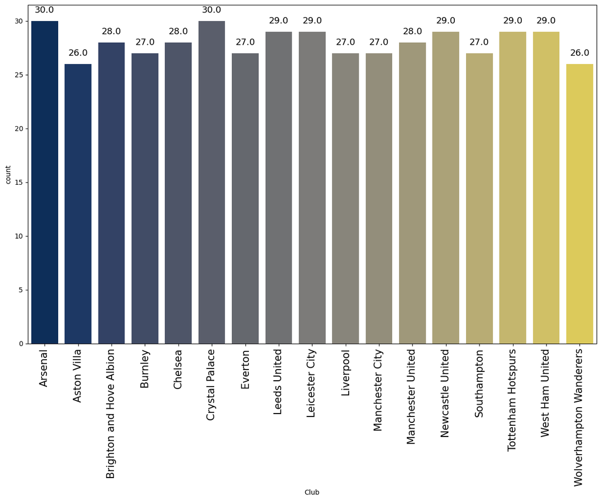

```python
plt.figure(figsize=(15,9))
ax = sns.countplot(data=df_fancy, x='Club', palette='cividis')
plt.xticks(rotation=90, fontsize=15);
for i in ax.patches:
    label = i.get_height()
    x = i.get_x() + i.get_width()/2
    y = i.get_height() + 1
    ax.annotate(label, (x,y), ha='center',
            va = 'center', size=13,
            )
```

- As mentioned before number of players in each club is uniformly distributed between 26 to 30 players.

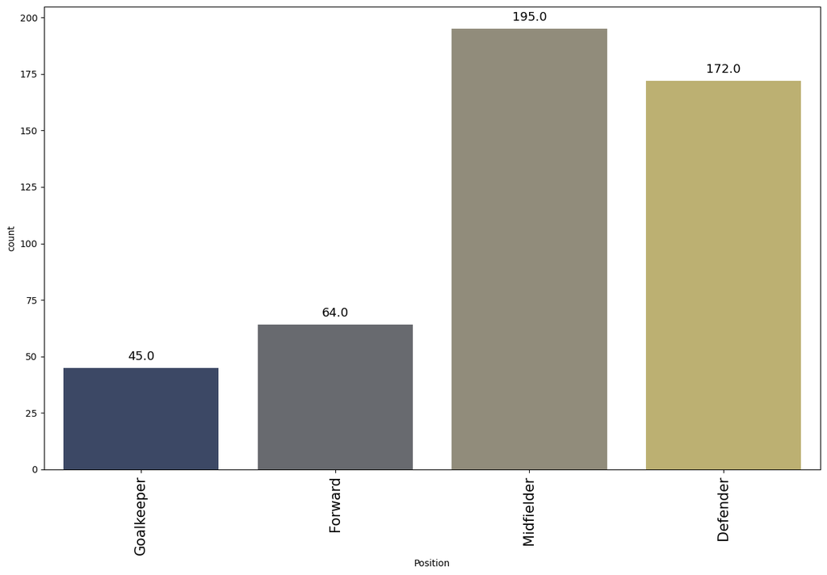

```python
plt.figure(figsize=(15,9))
ax = sns.countplot(data=df_fancy, x='Position', palette='cividis')
plt.xticks(rotation=90, fontsize=15);
for i in ax.patches:
    label = i.get_height()
    x = i.get_x() + i.get_width()/2
    y = i.get_height() + 5
    ax.annotate(label, (x,y), ha='center',
            va = 'center', size=13,
            )
```

- Again as mentioned before the number of midfielder is higher the highest.
- The number of goal keeper are the least which makes sense since you only need 1 goal keeper and 1 in squad.
- Defender are 3 times almost more than forwards which is due to the fact the teams like defend format more these days.

## Data Visualization - Bivariate data

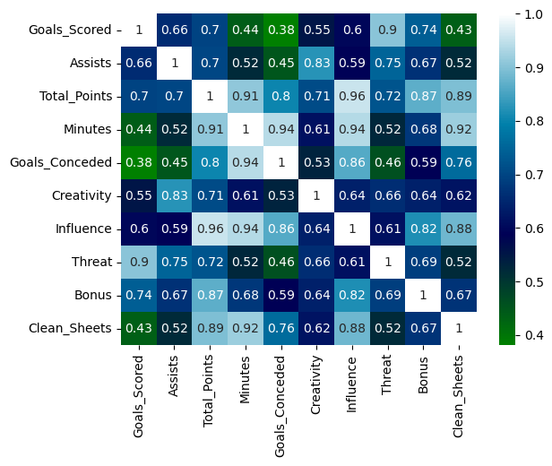

```python
Num_columns = df_fancy.select_dtypes(include=np.number).columns.tolist()
sns.heatmap(data=df_fancy[Num_columns].corr(), annot=True, cmap='ocean')
```

- The Goal scored by each player is highely correlated with threat.
- Total of points is highly correlated with clean_sheets, Bonus, Influence, Goal Conceded, and Minutes.
- There is no negative correlation in the dataset.

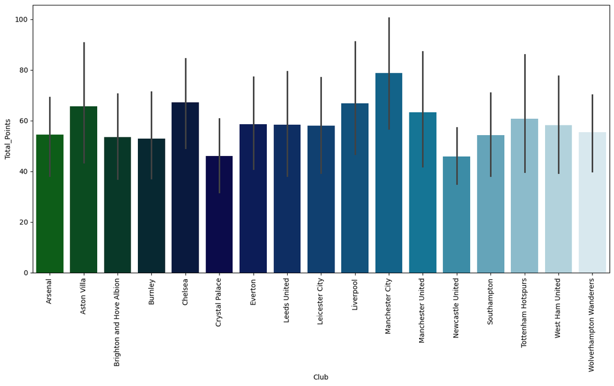

```python
plt.figure(figsize=(15,7))
sns.barplot(data = df_fancy, x = 'Club', y= 'Total_Points',  palette='ocean');
plt.xticks(rotation =90);
```

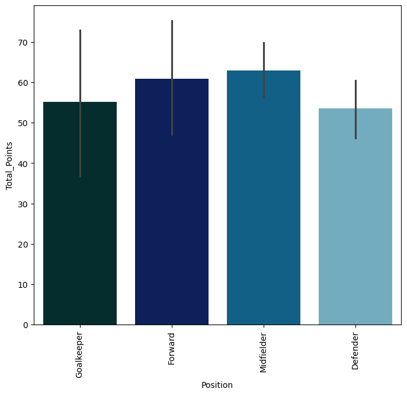

```python
plt.figure(figsize=(8,7))
sns.barplot(data = df_fancy, x = 'Position', y= 'Total_Points',  palette='ocean');
plt.xticks(rotation =90);
```

```python
df_fancy.groupby(['Position'])['Total_Points'].max()
```

```
Position
Defender      171
Forward       242
Goalkeeper    186
Midfielder    244
Name: Total_Points, dtype: int64
```

```python
df_fancy[df_fancy['Total_Points'] == 242]
```

|  | Player_Name | Club | Position | Goals_Scored | Assists | Total_Points | Minutes | Goals_Conceded | Creativity | Influence | Threat | Bonus | Clean_Sheets |
| --- | --- | --- | --- | --- | --- | --- | --- | --- | --- | --- | --- | --- | --- |
| 403 | Harry Kane | Tottenham Hotspurs | Forward | 23 | 14 | 242 | 3083 | 39 | 659.1 | 1318.2 | 1585 | 40 | 12 |

- Midfilder socre highest average total points.

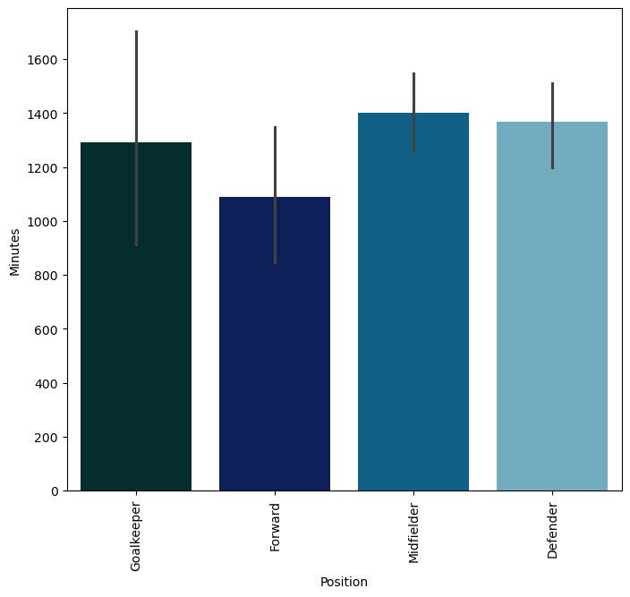

```python
plt.figure(figsize=(8,7))
sns.barplot(data = df_fancy, x = 'Position', y= 'Minutes',  palette='ocean');
plt.xticks(rotation =90);
```

- Players in the midfielder and defenders tends to play more minutes on average compare to the forward and goal keepers.

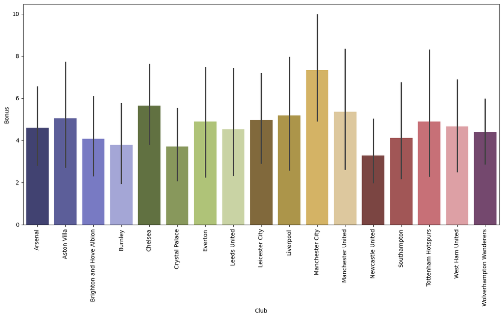

```python
plt.figure(figsize=(15,7))
sns.barplot(data = df_fancy, x = 'Club', y= 'Bonus',  palette='tab20b');
plt.xticks(rotation =90);
```

- Manchaster city players recieved highest bonus on average.

```python
pos_list = df_fancy.Position.unique().tolist()
best_df = pd.DataFrame()

for pos in pos_list:
    df_check = df_fancy[df_fancy['Position'] == pos]
    best_df = best_df.append(df_check[df_check['Total_Points'] == df_check.Total_Points.max()][['Player_Name', 'Club', 'Position', 'Total_Points']])

best_df
```

|  | Player_Name | Club | Position | Total_Points |
| --- | --- | --- | --- | --- |
| 36 | Emiliano Martinez | Aston Villa | Goalkeeper | 186 |
| 403 | Harry Kane | Tottenham Hotspurs | Forward | 242 |
| 315 | Bruno Fernandes | Manchester United | Midfielder | 244 |
| 223 | Stuart Dallas | Leeds United | Defender | 171 |

```python
best10_df = pd.DataFrame()

for pos in pos_list:
    df_check = df_fancy[df_fancy.Position==pos]
    best10_df = best10_df.append(df_check.sort_values('Total_Points', ascending=False).reset_index(drop=True).loc[:10, ['Player_Name', 'Club', 'Position', 'Total_Points']])

best10_df
```

|  | Player_Name | Club | Position | Total_Points |
| --- | --- | --- | --- | --- |
| 0 | Emiliano Martinez | Aston Villa | Goalkeeper | 186 |
| 1 | Ederson Moares | Manchester City | Goalkeeper | 160 |
| 2 | Illan Meslier | Leeds United | Goalkeeper | 154 |
| 3 | Hugo Lloris | Tottenham Hotspurs | Goalkeeper | 149 |
| 4 | Nick Pope | Burnley | Goalkeeper | 144 |
| 5 | Alisson Becker | Liverpool | Goalkeeper | 140 |
| 6 | Edouard Mendy | Chelsea | Goalkeeper | 140 |
| 7 | Lukasz Fabianski | West Ham United | Goalkeeper | 133 |
| 8 | Rui Pedro Patricio | Wolverhampton Wanderers | Goalkeeper | 132 |
| 9 | Bernd Leno | Arsenal | Goalkeeper | 131 |
| 10 | Kasper Schmeichel | Leicester City | Goalkeeper | 128 |
| 0 | Harry Kane | Tottenham Hotspurs | Forward | 242 |
| 1 | Patrick Bamford | Leeds United | Forward | 194 |
| 2 | Jamie Vardy | Leicester City | Forward | 187 |
| 3 | Ollie Watkins | Aston Villa | Forward | 168 |
| 4 | Dominic Calvert-Lewin | Everton | Forward | 165 |
| 5 | Roberto Firmino | Liverpool | Forward | 141 |
| 6 | Chris Wood | Burnley | Forward | 138 |
| 7 | Che Adams | Southampton | Forward | 137 |
| 8 | Callum Wilson | Newcastle United | Forward | 134 |
| 9 | Danny Ings | Southampton | Forward | 131 |
| 10 | Alexandre Lacazette | Arsenal | Forward | 129 |
| 0 | Bruno Fernandes | Manchester United | Midfielder | 244 |
| 1 | Mohamed Salah | Liverpool | Midfielder | 231 |
| 2 | Heung-Min Son | Tottenham Hotspurs | Midfielder | 228 |
| 3 | Sadio Mane | Liverpool | Midfielder | 176 |
| 4 | Marcus Rashford | Manchester United | Midfielder | 174 |
| 5 | Jack Harrison | Leeds United | Midfielder | 160 |
| 6 | Ilkay Gundogan | Manchester City | Midfielder | 157 |
| 7 | James Ward-Prowse | Southampton | Midfielder | 156 |
| 8 | Raheem Sterling | Manchester City | Midfielder | 154 |
| 9 | Tomas Soucek | West Ham United | Midfielder | 147 |
| 10 | Mason Mount | Chelsea | Midfielder | 147 |
| 0 | Stuart Dallas | Leeds United | Defender | 171 |
| 1 | Andrew Robertson | Liverpool | Defender | 161 |
| 2 | Trent Alexander-Arnold | Liverpool | Defender | 160 |
| 3 | Aaron Cresswell | West Ham United | Defender | 153 |
| 4 | Aaron Wan-Bissaka | Manchester United | Defender | 144 |
| 5 | Ruben Dias | Manchester City | Defender | 142 |
| 6 | Benjamin Chilwell | Chelsea | Defender | 139 |
| 7 | Matt Targett | Aston Villa | Defender | 138 |
| 8 | Joao Cancelo | Manchester City | Defender | 138 |
| 9 | Lewis Dunk | Brighton and Hove Albion | Defender | 130 |
| 10 | John Stones | Manchester City | Defender | 128 |

## Scaling Data

```python
scale = StandardScaler()
df_subset = df_fancy.iloc[:,3:].copy()
df_subset_scaled = pd.DataFrame(scale.fit_transform(df_subset), columns=df_subset.columns)
```

```python
df_subset_scaled.head()
```

|  | Goals_Scored | Assists | Total_Points | Minutes | Goals_Conceded | Creativity | Influence | Threat | Bonus | Clean_Sheets |
| --- | --- | --- | --- | --- | --- | --- | --- | --- | --- | --- |
| 0 | -0.552608 | -0.647555 | -1.122506 | -1.232383 | -1.202653 | -0.780115 | -1.039325 | -0.707638 | -0.755435 | -1.081123 |
| 1 | 3.213401 | 0.461208 | 1.375560 | 0.539871 | 0.115663 | 0.443542 | 1.150596 | 1.799393 | 2.606688 | 0.513521 |
| 2 | -0.552608 | -0.647555 | 1.414592 | 1.672585 | 1.120094 | -0.780115 | 1.523682 | -0.701346 | 1.005677 | 1.424747 |
| 3 | 0.895857 | 1.200384 | 1.082818 | 1.134662 | 0.743432 | 1.809706 | 0.741621 | 2.387618 | 0.525374 | 0.741328 |
| 4 | -0.552608 | 0.461208 | -0.439441 | -0.546229 | -0.574884 | -0.105790 | -0.459134 | -0.465428 | -0.275132 | -0.625510 |

## PCA Anaylsis

```python
n= df_subset_scaled.shape[1]

pca = PCA(n_components=df_subset_scaled.shape[1], random_state=1)

df_pca = pd.DataFrame(pca.fit_transform(df_subset_scaled))

pca_var = pca.explained_variance_ratio_
```

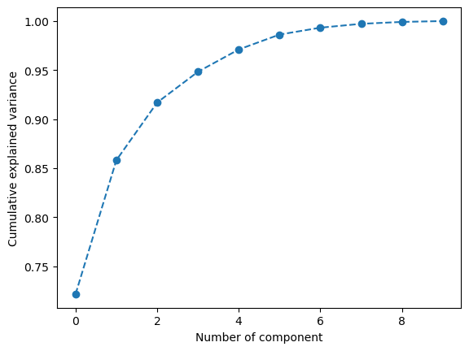

```python
plt.plot(range(n), pca_var.cumsum(), marker = 'o', linestyle='--')
plt.xlabel('Number of component')
plt.ylabel('Cumulative explained variance')
```

```python
sum = 0
for index, val in enumerate(pca_var):
    sum += val
    if sum>0.90:
        print(index)
        break
```

```
2
```

```python
pc_comps = ['PC1', 'PC2']
df_pca2 = pd.DataFrame(np.round(pca.components_[:2,:],2), index=pc_comps, columns=df_subset_scaled.columns)
df_pca2.T
```

|  | PC1 | PC2 |
| --- | --- | --- |
| Goals_Scored | 0.28 | 0.46 |
| Assists | 0.29 | 0.35 |
| Total_Points | 0.36 | -0.08 |
| Minutes | 0.33 | -0.37 |
| Goals_Conceded | 0.30 | -0.39 |
| Creativity | 0.30 | 0.19 |
| Influence | 0.35 | -0.22 |
| Threat | 0.30 | 0.42 |
| Bonus | 0.32 | 0.12 |
| Clean_Sheets | 0.32 | -0.31 |

- This explain what is the linear relation of the PC1 and PC2 with each features.

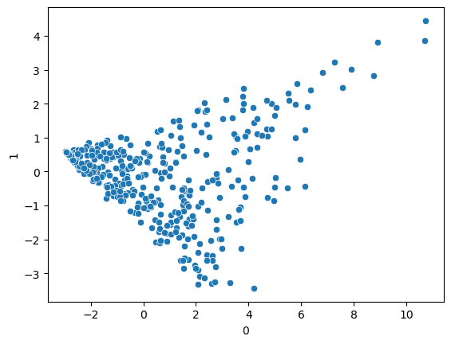

```python
sns.scatterplot(x=df_pca[0], y=df_pca[1])
```

## K-Means Clustering

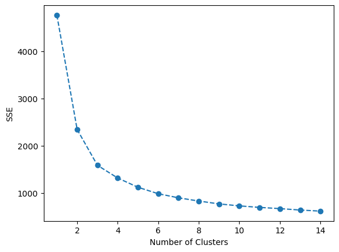

```python
sse = {}
for k in range(1,15):
    kmeans =KMeans(n_clusters= k , random_state=1).fit(df_pca)
    sse[k] = kmeans.inertia_

plt.plot(list(sse.keys()), list(sse.values()), marker = 'o', linestyle = '--')
plt.xlabel('Number of Clusters')
plt.ylabel('SSE')
```

- Elbow happens at 4 clusters.

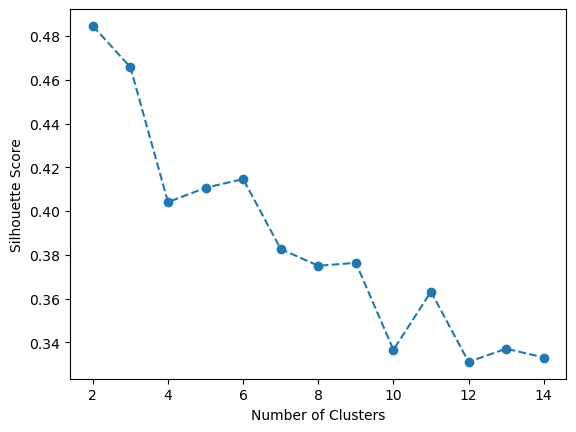

```python
sc = {}
for k in range(2,15):
    kmeans =KMeans(n_clusters= k , random_state=1).fit(df_pca)
    label = kmeans.predict(df_pca)
    sc[k] = silhouette_score(df_pca, label)

plt.plot(list(sc.keys()), list(sc.values()), marker = 'o', linestyle = '--')
plt.xlabel('Number of Clusters')
plt.ylabel('Silhouette Score')
```

- Silhaoutte score doesn't provide a better suppostion for k.

```python
kmeans= KMeans(n_clusters=4, random_state=1)
kmeans.fit(df_pca)

df_pca_copy = df_pca.copy()
df_fancy['K-Means Label'] = kmeans.labels_
df_pca_copy['K-Means Label'] = kmeans.labels_
df_fancy.head()
```

|  | Player_Name | Club | Position | Goals_Scored | Assists | Total_Points | Minutes | Goals_Conceded | Creativity | Influence | Threat | Bonus | Clean_Sheets | K-Means Label |
| --- | --- | --- | --- | --- | --- | --- | --- | --- | --- | --- | --- | --- | --- | --- |
| 0 | Alex Runnarsson | Arsenal | Goalkeeper | 0 | 0 | 1 | 15 | 0 | 0.0 | 16.6 | 0 | 0 | 0 | 3 |
| 1 | Alexandre Lacazette | Arsenal | Forward | 13 | 3 | 129 | 1916 | 21 | 307.4 | 602.4 | 797 | 21 | 7 | 2 |
| 2 | Bernd Leno | Arsenal | Goalkeeper | 0 | 0 | 131 | 3131 | 37 | 0.0 | 702.2 | 2 | 11 | 11 | 1 |
| 3 | Bukayo Saka | Arsenal | Midfielder | 5 | 5 | 114 | 2554 | 31 | 650.6 | 493.0 | 984 | 8 | 8 | 2 |
| 4 | Calum Chambers | Arsenal | Defender | 0 | 3 | 36 | 751 | 10 | 169.4 | 171.8 | 77 | 3 | 2 | 0 |

```python
df_fancy['K-Means Label'].value_counts()
```

```
3    188
0    128
1     99
2     61
Name: K-Means Label, dtype: int64
```

```python
df_fancy.groupby(['K-Means Label', 'Position'])['Player_Name'].count()
```

```
K-Means Label  Position
0              Defender      47
               Forward       16
               Goalkeeper     3
               Midfielder    62
1              Defender      50
               Goalkeeper    17
               Midfielder    32
2              Defender       5
               Forward       20
               Midfielder    36
3              Defender      70
               Forward       28
               Goalkeeper    25
               Midfielder    65
Name: Player_Name, dtype: int64
```

- Cluster 1 had no Forward player in it. It has more player in the defense. It is on defense
- Cluster 2 has no Goalkeepers in it. It hs more midfielder and forward players. It is on offense.

```python
df_fancy.groupby(['K-Means Label']).mean().style.highlight_max(color='green')
```

| K-Means Label | Goals_Scored | Assists | Total_Points | Minutes | Goals_Conceded | Creativity | Influence | Threat | Bonus | Clean_Sheets |
| --- | --- | --- | --- | --- | --- | --- | --- | --- | --- | --- |
| 0 | 1.460938 | 1.601562 | 55.648438 | 1389.453125 | 20.554688 | 187.653125 | 270.037500 | 218.117188 | 3.312500 | 4.687500 |
| 1 | 1.363636 | 1.878788 | 103.525253 | 2670.555556 | 37.525253 | 265.671717 | 579.185859 | 199.636364 | 7.676768 | 10.020202 |
| 2 | 9.147541 | 6.639344 | 141.557377 | 2446.704918 | 33.344262 | 617.495082 | 659.324590 | 880.540984 | 16.147541 | 9.213115 |
| 3 | 0.148936 | 0.202128 | 9.824468 | 238.750000 | 3.930851 | 28.171809 | 43.164894 | 30.244681 | 0.409574 | 0.558511 |

```python
df_fancy.groupby(['K-Means Label']).mean().style.highlight_min(color='red')
```

| K-Means Label | Goals_Scored | Assists | Total_Points | Minutes | Goals_Conceded | Creativity | Influence | Threat | Bonus | Clean_Sheets |
| --- | --- | --- | --- | --- | --- | --- | --- | --- | --- | --- |
| 0 | 1.460938 | 1.601562 | 55.648438 | 1389.453125 | 20.554688 | 187.653125 | 270.037500 | 218.117188 | 3.312500 | 4.687500 |
| 1 | 1.363636 | 1.878788 | 103.525253 | 2670.555556 | 37.525253 | 265.671717 | 579.185859 | 199.636364 | 7.676768 | 10.020202 |
| 2 | 9.147541 | 6.639344 | 141.557377 | 2446.704918 | 33.344262 | 617.495082 | 659.324590 | 880.540984 | 16.147541 | 9.213115 |
| 3 | 0.148936 | 0.202128 | 9.824468 | 238.750000 | 3.930851 | 28.171809 | 43.164894 | 30.244681 | 0.409574 | 0.558511 |

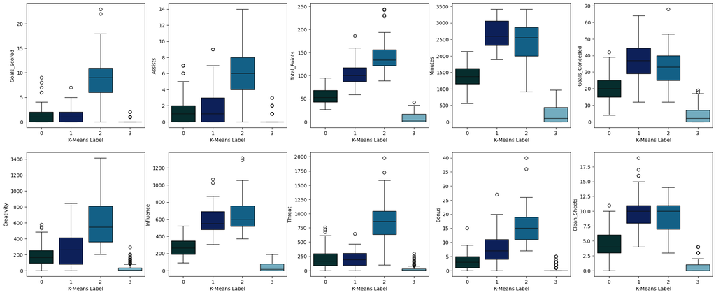

```python
fig, ax = plt.subplots(2, 5, figsize=(25,10))
for i in range(2):
    for j in range(5):
        sns.boxplot(data=df_fancy, x='K-Means Label', y = Num_columns[i*5+j], palette='ocean', ax=ax[i][j])

plt.show()
```

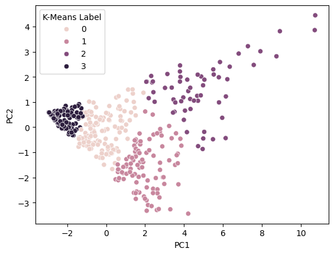

```python
sns.scatterplot(x=df_pca_copy[0], y=df_pca_copy[1], hue=df_pca_copy['K-Means Label']);
plt.xlabel('PC1')
plt.ylabel('PC2')
```

- Cluster 0
  - It has 128 player in it.
  - Most of these players score low goals, assists and total fanacy points scored.
  - Most of players has medium play time last year, and low level of cretivity and threat.
  - They mostly recieved low bonus.
- Cluster 1
  - They are 99 palyers in this cluster.
  - most the players score low goals, assists and total fancy points scrored is moderate.
  - on average players in this cluster has high game time, and high goal concended. moderate creativity, high influnce score.
  - They recieved moderate bonus.
- Cluster 2
  - They are 61 players in this cluster.
  - They score high goal and assist, and total points.
  - They recieved highest bonus.
  - They had high game time, creativity, influence and threat and scores.
- Cluster 3
  - They are 188 players in this group.
  - The score lowest goal, assist, total point.
  - They recieved alsmot no bonus.
  - They had low game time, low creativity, influence and threat scores.

## K-Medoid Clustering

```python
kmedos = KMedoids(n_clusters=4, random_state=1)
kmedos.fit(df_pca)

df_pca_copy2 = df_pca.copy()
df_fancy['K-Medoids Label'] = kmedos.labels_
df_pca_copy2['K-Medoids Label'] = kmedos.labels_
df_fancy.head()
```

|  | Player_Name | Club | Position | Goals_Scored | Assists | Total_Points | Minutes | Goals_Conceded | Creativity | Influence | Threat | Bonus | Clean_Sheets | K-Means Label | K-Medoids Label |
| --- | --- | --- | --- | --- | --- | --- | --- | --- | --- | --- | --- | --- | --- | --- | --- |
| 0 | Alex Runnarsson | Arsenal | Goalkeeper | 0 | 0 | 1 | 15 | 0 | 0.0 | 16.6 | 0 | 0 | 0 | 3 | 3 |
| 1 | Alexandre Lacazette | Arsenal | Forward | 13 | 3 | 129 | 1916 | 21 | 307.4 | 602.4 | 797 | 21 | 7 | 2 | 0 |
| 2 | Bernd Leno | Arsenal | Goalkeeper | 0 | 0 | 131 | 3131 | 37 | 0.0 | 702.2 | 2 | 11 | 11 | 1 | 1 |
| 3 | Bukayo Saka | Arsenal | Midfielder | 5 | 5 | 114 | 2554 | 31 | 650.6 | 493.0 | 984 | 8 | 8 | 2 | 0 |
| 4 | Calum Chambers | Arsenal | Defender | 0 | 3 | 36 | 751 | 10 | 169.4 | 171.8 | 77 | 3 | 2 | 0 | 2 |

```python
df_fancy['K-Medoids Label'].value_counts()
```

```
3    171
2    136
1     87
0     82
Name: K-Medoids Label, dtype: int64
```

```python
df_fancy.groupby(['K-Medoids Label', 'Position'])['Player_Name'].count()
```

```
K-Medoids Label  Position
0                Defender      12
                 Forward       21
                 Midfielder    49
1                Defender      49
                 Goalkeeper    17
                 Midfielder    21
2                Defender      50
                 Forward       16
                 Goalkeeper     3
                 Midfielder    67
3                Defender      61
                 Forward       27
                 Goalkeeper    25
                 Midfielder    58
Name: Player_Name, dtype: int64
```

- Cluster 0 doesn't have Goalkeeper
- Cluster 1 doesn't have Forward

```python
df_fancy.groupby(['K-Medoids Label']).mean().style.highlight_max(color='green')
```

| K-Medoids Label | Goals_Scored | Assists | Total_Points | Minutes | Goals_Conceded | Creativity | Influence | Threat | Bonus | Clean_Sheets | K-Means Label |
| --- | --- | --- | --- | --- | --- | --- | --- | --- | --- | --- | --- |
| 0 | 7.512195 | 6.195122 | 133.243902 | 2452.243902 | 33.853659 | 602.902439 | 625.653659 | 745.402439 | 14.573171 | 9.231707 | 1.719512 |
| 1 | 1.068966 | 1.091954 | 99.528736 | 2638.195402 | 36.632184 | 184.582759 | 575.818391 | 166.333333 | 6.988506 | 9.931034 | 0.919540 |
| 2 | 1.338235 | 1.558824 | 51.073529 | 1270.051471 | 18.977941 | 180.458824 | 242.588235 | 203.102941 | 2.904412 | 4.205882 | 0.375000 |
| 3 | 0.099415 | 0.111111 | 7.736842 | 193.187135 | 3.362573 | 18.979532 | 34.188304 | 22.608187 | 0.280702 | 0.385965 | 3.000000 |

```python
df_fancy.groupby(['K-Medoids Label']).mean().style.highlight_min(color='red')
```

| K-Medoids Label | Goals_Scored | Assists | Total_Points | Minutes | Goals_Conceded | Creativity | Influence | Threat | Bonus | Clean_Sheets | K-Means Label |
| --- | --- | --- | --- | --- | --- | --- | --- | --- | --- | --- | --- |
| 0 | 7.512195 | 6.195122 | 133.243902 | 2452.243902 | 33.853659 | 602.902439 | 625.653659 | 745.402439 | 14.573171 | 9.231707 | 1.719512 |
| 1 | 1.068966 | 1.091954 | 99.528736 | 2638.195402 | 36.632184 | 184.582759 | 575.818391 | 166.333333 | 6.988506 | 9.931034 | 0.919540 |
| 2 | 1.338235 | 1.558824 | 51.073529 | 1270.051471 | 18.977941 | 180.458824 | 242.588235 | 203.102941 | 2.904412 | 4.205882 | 0.375000 |
| 3 | 0.099415 | 0.111111 | 7.736842 | 193.187135 | 3.362573 | 18.979532 | 34.188304 | 22.608187 | 0.280702 | 0.385965 | 3.000000 |

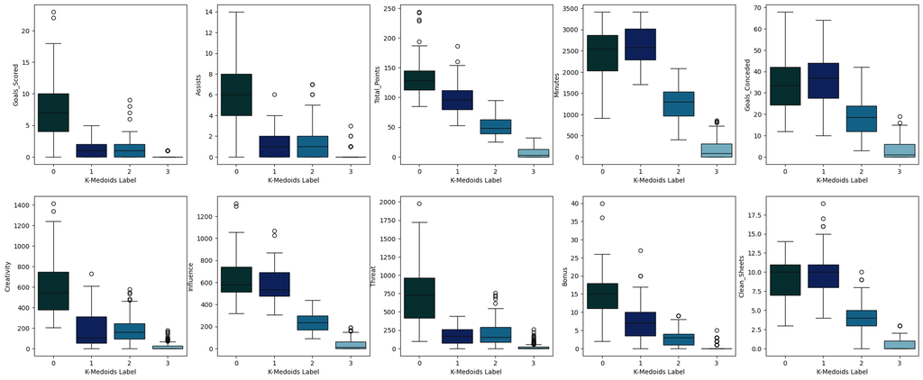

```python
fig, ax = plt.subplots(2, 5, figsize=(25,10))
for i in range(2):
    for j in range(5):
        sns.boxplot(data=df_fancy, x='K-Medoids Label', y = Num_columns[i*5+j], palette='ocean', ax=ax[i][j])

plt.show()
```

- K-Medoids clusters are more evenly distributed and the cluster profiles remain the same between K-means and K-medoids.
- Cluster 0
  - There are 82 players in this cluster.
  - Most of the players in this dataset has high goal score, assists, abd total points scored.
  - Most of the players has moderate to high play time and high creativity, influence and threat
  - Most of the player in this group goup highest bonus point.
  - Most of them recieved moderate to high clean sheet.
  - No goal keeper in this cluster.
- Cluster 1
  - There are 87 players in this cluster.
  - Most of the players in this dataset has few goal score, assists and total points scored.
  - Most of the players has high play time and moderate creativity, high influence and low threat
  - Most of the player in this group recieve moderate bonus point.
  - Most of them recieved high clean sheet.
  - No Forward in this cluster.
- Cluster 2
  - There are 136 players in this cluster.
  - Most of the players in this dataset has moderate goal score, assists and total points scored.
  - Most of the players has moderate play time and low creativity, influence and threat
  - Most of the player in this group recieve low bonus point.
  - Most of them recieved low clean sheet.
- Cluster 3
  - There are 171 players in this cluster.
  - Most of the players in this dataset has least goal score, assists and total points scored.
  - Most of the players has lowest play time and least creativity, influence and threat
  - Most of the player in this group recieve lowest bonus point.
  - Most of them recieved lowest clean sheet.

## Gaussian Mixture Clustering

```python
gmm = GaussianMixture(n_components=4, random_state=1)
gmm.fit(df_pca)

df_fancy['GMM Labels'] = gmm.fit_predict(df_pca)
df_pca_copy2['GMM Labels'] = gmm.fit_predict(df_pca)
```

```python
df_fancy.head()
```

|  | Player_Name | Club | Position | Goals_Scored | Assists | Total_Points | Minutes | Goals_Conceded | Creativity | Influence | Threat | Bonus | Clean_Sheets | K-Means Label | K-Medoids Label | GMM Labels |
| --- | --- | --- | --- | --- | --- | --- | --- | --- | --- | --- | --- | --- | --- | --- | --- | --- |
| 0 | Alex Runnarsson | Arsenal | Goalkeeper | 0 | 0 | 1 | 15 | 0 | 0.0 | 16.6 | 0 | 0 | 0 | 3 | 3 | 1 |
| 1 | Alexandre Lacazette | Arsenal | Forward | 13 | 3 | 129 | 1916 | 21 | 307.4 | 602.4 | 797 | 21 | 7 | 2 | 0 | 2 |
| 2 | Bernd Leno | Arsenal | Goalkeeper | 0 | 0 | 131 | 3131 | 37 | 0.0 | 702.2 | 2 | 11 | 11 | 1 | 1 | 0 |
| 3 | Bukayo Saka | Arsenal | Midfielder | 5 | 5 | 114 | 2554 | 31 | 650.6 | 493.0 | 984 | 8 | 8 | 2 | 0 | 2 |
| 4 | Calum Chambers | Arsenal | Defender | 0 | 3 | 36 | 751 | 10 | 169.4 | 171.8 | 77 | 3 | 2 | 0 | 2 | 3 |

```python
df_fancy['GMM Labels'].value_counts()
```

```
3    129
1    126
0    116
2    105
Name: GMM Labels, dtype: int64
```

```python
df_fancy.groupby(['GMM Labels', 'Position'])['Player_Name'].count()
```

```
GMM Labels  Position
0           Defender      64
            Goalkeeper    18
            Midfielder    34
1           Defender      48
            Forward       21
            Goalkeeper    19
            Midfielder    38
2           Defender      10
            Forward       32
            Midfielder    63
3           Defender      50
            Forward       11
            Goalkeeper     8
            Midfielder    60
Name: Player_Name, dtype: int64
```

- Cluster 0 has no Forward in it.
- Cluster 2 has no GoalKeeper in it.

```python
df_fancy.groupby(['GMM Labels']).mean().style.highlight_max(color='green')
```

| GMM Labels | Goals_Scored | Assists | Total_Points | Minutes | Goals_Conceded | Creativity | Influence | Threat | Bonus | Clean_Sheets | K-Means Label | K-Medoids Label |
| --- | --- | --- | --- | --- | --- | --- | --- | --- | --- | --- | --- | --- |
| 0 | 1.189655 | 1.344828 | 94.439655 | 2453.189655 | 33.793103 | 221.881897 | 535.862069 | 174.991379 | 6.793103 | 9.431034 | 0.758621 | 1.120690 |
| 1 | 0.000000 | 0.000000 | 3.547619 | 107.436508 | 2.055556 | 8.590476 | 15.739683 | 5.746032 | 0.000000 | 0.182540 | 3.000000 | 2.992063 |
| 2 | 6.552381 | 5.390476 | 114.876190 | 2104.809524 | 29.619048 | 501.710476 | 521.451429 | 683.466667 | 11.904762 | 7.685714 | 1.266667 | 0.580952 |
| 3 | 0.635659 | 0.868217 | 34.031008 | 908.968992 | 14.186047 | 106.855039 | 165.444961 | 110.813953 | 1.612403 | 2.596899 | 1.441860 | 2.356589 |

```python
df_fancy.groupby(['GMM Labels']).mean().style.highlight_min(color='red')
```

| GMM Labels | Goals_Scored | Assists | Total_Points | Minutes | Goals_Conceded | Creativity | Influence | Threat | Bonus | Clean_Sheets | K-Means Label | K-Medoids Label |
| --- | --- | --- | --- | --- | --- | --- | --- | --- | --- | --- | --- | --- |
| 0 | 1.189655 | 1.344828 | 94.439655 | 2453.189655 | 33.793103 | 221.881897 | 535.862069 | 174.991379 | 6.793103 | 9.431034 | 0.758621 | 1.120690 |
| 1 | 0.000000 | 0.000000 | 3.547619 | 107.436508 | 2.055556 | 8.590476 | 15.739683 | 5.746032 | 0.000000 | 0.182540 | 3.000000 | 2.992063 |
| 2 | 6.552381 | 5.390476 | 114.876190 | 2104.809524 | 29.619048 | 501.710476 | 521.451429 | 683.466667 | 11.904762 | 7.685714 | 1.266667 | 0.580952 |
| 3 | 0.635659 | 0.868217 | 34.031008 | 908.968992 | 14.186047 | 106.855039 | 165.444961 | 110.813953 | 1.612403 | 2.596899 | 1.441860 | 2.356589 |

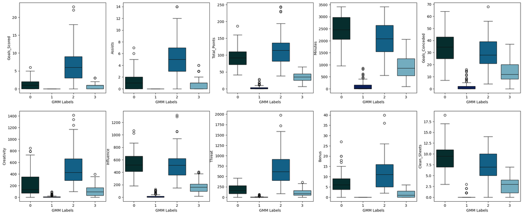

```python
fig, ax = plt.subplots(2, 5, figsize=(25,10))
for i in range(2):
    for j in range(5):
        sns.boxplot(data=df_fancy, x='GMM Labels', y = Num_columns[i*5+j], palette='ocean', ax=ax[i][j])

plt.show()
```

## Hierarchical Clustering (Agglomerative Clustering)

```python
# List of distance metrics
distance_metrics = ['euclidean', 'chebyshev',  'mahalanobis', 'cityblock']

# List of linkage methods
linkage_methods = ['single', 'average', 'complete', 'weighted']

high_cophenet_corr = 0
high_dm_lm = [0, 0]

for dm in distance_metrics:
    for lm in linkage_methods:
        Z = linkage(df_pca, metric = dm, method = lm)
        c, coph_dists = cophenet(Z, pdist(df_pca))
        print(
            "Cophenetic correlation for {} distance and {} linkage is {}.".format(
                dm.capitalize(), lm, c
            )
        )
        if high_cophenet_corr < c:
            high_cophenet_corr = c
            high_dm_lm[0] = dm
            high_dm_lm[1] = lm

# Printing the combination of distance metric and linkage method with the highest cophenetic correlation
print('*'*100)
print(
    "Highest cophenetic correlation is {}, which is obtained with {} distance and {} linkage.".format(
        high_cophenet_corr, high_dm_lm[0].capitalize(), high_dm_lm[1]
    )
)
```

```
Cophenetic correlation for Euclidean distance and single linkage is 0.8430175514228708.
Cophenetic correlation for Euclidean distance and average linkage is 0.8476499945585417.
Cophenetic correlation for Euclidean distance and complete linkage is 0.741204129226176.
Cophenetic correlation for Euclidean distance and weighted linkage is 0.8624581351067481.
Cophenetic correlation for Chebyshev distance and single linkage is 0.8381223141111798.
Cophenetic correlation for Chebyshev distance and average linkage is 0.8167064931302255.
Cophenetic correlation for Chebyshev distance and complete linkage is 0.8028394390632132.
Cophenetic correlation for Chebyshev distance and weighted linkage is 0.844849787663964.
Cophenetic correlation for Mahalanobis distance and single linkage is 0.8065008904132245.
Cophenetic correlation for Mahalanobis distance and average linkage is 0.7747800632434059.
Cophenetic correlation for Mahalanobis distance and complete linkage is 0.6583135946489013.
Cophenetic correlation for Mahalanobis distance and weighted linkage is 0.6486408054242748.
Cophenetic correlation for Cityblock distance and single linkage is 0.840183551166332.
Cophenetic correlation for Cityblock distance and average linkage is 0.8564523087071935.
Cophenetic correlation for Cityblock distance and complete linkage is 0.8241586035407029.
Cophenetic correlation for Cityblock distance and weighted linkage is 0.8395672301050403.
Highest cophenetic correlation is 0.8624581351067481, which is obtained with Euclidean distance and weighted linkage.
```

```python
# List of linkage methods
linkage_methods = ["single", "complete", "average", "centroid", "ward", "weighted"]

high_cophenet_corr = 0
high_dm_lm = [0, 0]

for lm in linkage_methods:
    Z = linkage(df_pca, metric = "euclidean", method = lm)
    c, coph_dists = cophenet(Z, pdist(df_pca))
    print("Cophenetic correlation for {} linkage is {}.".format(lm, c))
    if high_cophenet_corr < c:
        high_cophenet_corr = c
        high_dm_lm[0] = "euclidean"
        high_dm_lm[1] = lm

# Printing the combination of distance metric and linkage method with the highest cophenetic correlation
print('*'*100)
print(
    "Highest cophenetic correlation is {}, which is obtained with {} linkage.".format(
        high_cophenet_corr, high_dm_lm[1]
    )
)
```

```
Cophenetic correlation for single linkage is 0.8430175514228708.
Cophenetic correlation for complete linkage is 0.741204129226176.
Cophenetic correlation for average linkage is 0.8476499945585417.
Cophenetic correlation for centroid linkage is 0.8068296032280465.
Cophenetic correlation for ward linkage is 0.577773844586155.
Cophenetic correlation for weighted linkage is 0.8624581351067481.
Highest cophenetic correlation is 0.8624581351067481, which is obtained with weighted linkage.
```

- Cophenetic correlation is maximum with Euclidean distance and weighted Linkage.

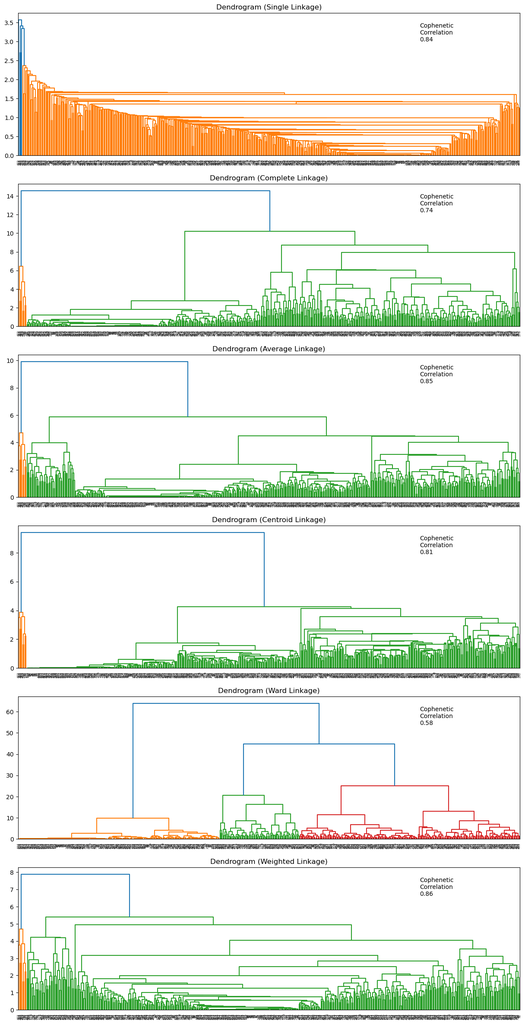

```python
# List of linkage methods
linkage_methods = ["single", "complete", "average", "centroid", "ward", "weighted"]

# Lists to save results of cophenetic correlation calculation
compare_cols = ["Linkage", "Cophenetic Coefficient"]
compare = []

# To create a subplot image
fig, axs = plt.subplots(len(linkage_methods), 1, figsize = (15, 30))

# We will enumerate through the list of linkage methods above
# For each linkage method, we will plot the dendrogram and calculate the cophenetic correlation
for i, method in enumerate(linkage_methods):
    Z = linkage(df_pca, metric = "euclidean", method = method)

    dendrogram(Z, ax = axs[i])
    axs[i].set_title(f"Dendrogram ({method.capitalize()} Linkage)")

    coph_corr, coph_dist = cophenet(Z, pdist(df_pca))
    axs[i].annotate(
        f"Cophenetic\nCorrelation\n{coph_corr:0.2f}",
        (0.80, 0.80),
        xycoords="axes fraction",
    )

    compare.append([method, coph_corr])
```

```python
# Create and print a dataframe to compare cophenetic correlations for different linkage methods
df_cc = pd.DataFrame(compare, columns = compare_cols)

df_cc = df_cc.sort_values(by = "Cophenetic Coefficient")
df_cc
```

|  | Linkage | Cophenetic Coefficient |
| --- | --- | --- |
| 4 | ward | 0.577774 |
| 1 | complete | 0.741204 |
| 3 | centroid | 0.806830 |
| 0 | single | 0.843018 |
| 2 | average | 0.847650 |
| 5 | weighted | 0.862458 |

- Scikit learn can't support weighted linkage. So let's use the average that gives highest cophenetic Coefficient. We are going to apply 4 cluster for this and of course with Euclidean distance.

```python
hc_agg = AgglomerativeClustering(n_clusters= 4, affinity='euclidean', linkage= 'average' )
hc_agg.fit(df_pca)

df_fancy['HC lalbel'] = hc_agg.labels_
df_pca_copy['HC lalbel'] = hc_agg.labels_
```

```python
df_fancy['HC lalbel'].value_counts()
```

```
0    422
2     46
1      5
3      3
Name: HC lalbel, dtype: int64
```

```python
df_fancy.groupby(['HC lalbel', 'Position'])['Player_Name'].count()
```

```
HC lalbel  Position
0          Defender      171
           Forward        43
           Goalkeeper     45
           Midfielder    163
1          Forward         4
           Midfielder      1
2          Defender        1
           Forward        16
           Midfielder     29
3          Forward         1
           Midfielder      2
Name: Player_Name, dtype: int64
```

```python
df_fancy.groupby(['HC lalbel']).mean().style.highlight_max(color='green')
```

| HC lalbel | Goals_Scored | Assists | Total_Points | Minutes | Goals_Conceded | Creativity | Influence | Threat | Bonus | Clean_Sheets | K-Means Label | K-Medoids Label | GMM Labels |
| --- | --- | --- | --- | --- | --- | --- | --- | --- | --- | --- | --- | --- | --- |
| 0 | 0.881517 | 1.139810 | 47.969194 | 1205.945498 | 17.580569 | 148.574408 | 249.536967 | 131.753555 | 3.293839 | 4.182464 | 1.609005 | 2.066351 | 1.457346 |
| 1 | 16.800000 | 9.200000 | 189.000000 | 3033.200000 | 44.000000 | 494.340000 | 860.720000 | 1591.600000 | 21.800000 | 10.800000 | 2.000000 | 0.000000 | 2.000000 |
| 2 | 8.565217 | 5.826087 | 129.391304 | 2238.934783 | 29.760870 | 543.273913 | 586.234783 | 861.739130 | 14.021739 | 8.739130 | 1.956522 | 0.000000 | 2.000000 |
| 3 | 19.333333 | 13.000000 | 238.000000 | 3101.000000 | 37.000000 | 1041.300000 | 1221.000000 | 1294.666667 | 34.000000 | 12.666667 | 2.000000 | 0.000000 | 2.000000 |

```python
df_fancy.groupby(['HC lalbel']).mean().style.highlight_min(color='red')
```

| HC lalbel | Goals_Scored | Assists | Total_Points | Minutes | Goals_Conceded | Creativity | Influence | Threat | Bonus | Clean_Sheets | K-Means Label | K-Medoids Label | GMM Labels |
| --- | --- | --- | --- | --- | --- | --- | --- | --- | --- | --- | --- | --- | --- |
| 0 | 0.881517 | 1.139810 | 47.969194 | 1205.945498 | 17.580569 | 148.574408 | 249.536967 | 131.753555 | 3.293839 | 4.182464 | 1.609005 | 2.066351 | 1.457346 |
| 1 | 16.800000 | 9.200000 | 189.000000 | 3033.200000 | 44.000000 | 494.340000 | 860.720000 | 1591.600000 | 21.800000 | 10.800000 | 2.000000 | 0.000000 | 2.000000 |
| 2 | 8.565217 | 5.826087 | 129.391304 | 2238.934783 | 29.760870 | 543.273913 | 586.234783 | 861.739130 | 14.021739 | 8.739130 | 1.956522 | 0.000000 | 2.000000 |
| 3 | 19.333333 | 13.000000 | 238.000000 | 3101.000000 | 37.000000 | 1041.300000 | 1221.000000 | 1294.666667 | 34.000000 | 12.666667 | 2.000000 | 0.000000 | 2.000000 |

- Cluster 1 and 3 has almost no data in it while cluster 0 has all of the data. This doesn't seem to be a good method let's change it to the Ward method.

```python
hc_agg = AgglomerativeClustering(n_clusters= 4, affinity='euclidean', linkage= 'ward' )
hc_agg.fit(df_pca)

df_fancy['HC Label'] = hc_agg.labels_
df_pca_copy['HC Label'] = hc_agg.labels_
```

```python
df_fancy['HC Label'].value_counts()
```

```
3    191
1    112
2     97
0     76
Name: HC Label, dtype: int64
```

```python
df_fancy.groupby(['HC Label', 'Position'])['Player_Name'].count()
```

```
HC Label  Position
0         Defender      10
          Forward       21
          Midfielder    45
1         Defender      38
          Forward       14
          Goalkeeper     3
          Midfielder    57
2         Defender      52
          Goalkeeper    17
          Midfielder    28
3         Defender      72
          Forward       29
          Goalkeeper    25
          Midfielder    65
Name: Player_Name, dtype: int64
```

```python
df_fancy.groupby(['HC Label']).mean().style.highlight_max(color='green')
```

| HC Label | Goals_Scored | Assists | Total_Points | Minutes | Goals_Conceded | Creativity | Influence | Threat | Bonus | Clean_Sheets | K-Means Label | K-Medoids Label | GMM Labels | HC lalbel |
| --- | --- | --- | --- | --- | --- | --- | --- | --- | --- | --- | --- | --- | --- | --- |
| 0 | 7.960526 | 6.342105 | 135.592105 | 2467.605263 | 33.802632 | 594.343421 | 638.431579 | 772.302632 | 14.736842 | 9.302632 | 1.763158 | 0.078947 | 1.789474 | 1.394737 |
| 1 | 1.357143 | 1.669643 | 53.812500 | 1367.767857 | 20.866071 | 186.037500 | 259.967857 | 218.866071 | 3.000000 | 4.437500 | 0.053571 | 1.964286 | 2.232143 | 0.000000 |
| 2 | 1.247423 | 1.206186 | 98.453608 | 2557.814433 | 35.371134 | 220.125773 | 556.723711 | 185.505155 | 7.237113 | 9.721649 | 0.896907 | 0.958763 | 0.164948 | 0.000000 |
| 3 | 0.157068 | 0.251309 | 10.324607 | 248.863874 | 4.094241 | 31.026702 | 45.018848 | 30.785340 | 0.460733 | 0.586387 | 2.921466 | 2.895288 | 1.680628 | 0.000000 |

```python
df_fancy.groupby(['HC Label']).mean().style.highlight_min(color='red')
```

| HC Label | Goals_Scored | Assists | Total_Points | Minutes | Goals_Conceded | Creativity | Influence | Threat | Bonus | Clean_Sheets | K-Means Label | K-Medoids Label | GMM Labels | HC lalbel |
| --- | --- | --- | --- | --- | --- | --- | --- | --- | --- | --- | --- | --- | --- | --- |
| 0 | 7.960526 | 6.342105 | 135.592105 | 2467.605263 | 33.802632 | 594.343421 | 638.431579 | 772.302632 | 14.736842 | 9.302632 | 1.763158 | 0.078947 | 1.789474 | 1.394737 |
| 1 | 1.357143 | 1.669643 | 53.812500 | 1367.767857 | 20.866071 | 186.037500 | 259.967857 | 218.866071 | 3.000000 | 4.437500 | 0.053571 | 1.964286 | 2.232143 | 0.000000 |
| 2 | 1.247423 | 1.206186 | 98.453608 | 2557.814433 | 35.371134 | 220.125773 | 556.723711 | 185.505155 | 7.237113 | 9.721649 | 0.896907 | 0.958763 | 0.164948 | 0.000000 |
| 3 | 0.157068 | 0.251309 | 10.324607 | 248.863874 | 4.094241 | 31.026702 | 45.018848 | 30.785340 | 0.460733 | 0.586387 | 2.921466 | 2.895288 | 1.680628 | 0.000000 |

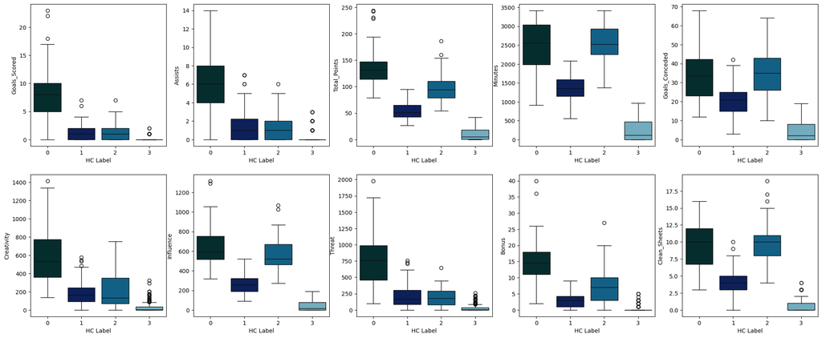

```python
fig, ax = plt.subplots(2, 5, figsize=(25,10))
for i in range(2):
    for j in range(5):
        sns.boxplot(data=df_fancy, x='HC Label', y = Num_columns[i*5+j], palette='ocean', ax=ax[i][j])

plt.show()
```

- Agglomerative cluster has two cluster with value and two high and low. The cluster profiles remain the same between K-means and K-medoids and agglomerative.
- Cluster 0
  - There are 76 players in this cluster.
  - Most of the players in this dataset has high goal score, assists, abd total points scored.
  - Most of the players has high play time, influence, creativity, and threat
  - Most of the player in this group have high bonus point.
  - Most of them recieved high clean sheet.
  - No Goalkeeper in this cluster.
- Cluster 1
  - There are 112 players in this cluster.
  - Most of the players in this dataset has scored a few goal, and assists and total points scored is low.
  - Most of the players has moderate play time and low creativity, influence and threat
  - Most of the player in this group recieve low bonus point.
  - Most of them recieved moderate clean sheet.
- Cluster 2
  - There are 97 players in this cluster.
  - Most of the players in this dataset has scored few goal and assists and moderate total points scored.
  - Most of the players has high play time and moderate creativity, and threat and high influence.
  - Most of the player in this group recieve moderate bonus point.
  - No Forward in this cluster.
  - Most of them recieved high clean sheet.
- Cluster 3
  - There are 191 players in this cluster.
  - Most of the players in this dataset have no goal score, assists and total points scored is low.
  - Most of the players has low play time, low creativity, influence and threat
  - Most of the player in this group recieve no bonus point.
  - Most of them recieved lowest clean sheet.

## DBSCAN Clustering

```python
# Initializing lists
eps_value = [2,3]           # Taking random eps value
min_sample_values = [6,20]  # Taking random min_sample value

# Creating a dictionary for each of the values in eps_value with min_sample_values
res = {eps_value[i]: min_sample_values for i in range(len(eps_value))}
```

```python
# Finding the silhouette_score for each of the combination

high_silhouette_avg = 0                                               # Assigning 0 to the high_silhouette_avg variable
high_i_j = [0, 0]                                                     # Assigning 0's to the high_i_j list
key = res.keys()                                                      # Assigning dictionary keys to a variable called key
for i in key:
    z = res[i]                                                        # Assigning dictionary values of each i to z
    for j in z:
        db = DBSCAN(eps = i, min_samples = j).fit(df_pca)          # Applying DBSCAN to each of the combinations in dictionary
        core_samples_mask = np.zeros_like(db.labels_, dtype = bool)
        core_samples_mask[db.core_sample_indices_] = True
        labels = db.labels_
        silhouette_avg = silhouette_score(df_pca, labels)          # Finding silhouette score
        print(
            "For eps value =" + str(i),
            "For min sample =" + str(j),
            "The average silhoutte_score is :",
            silhouette_avg,                                          # Printing the silhouette score for each of the combination
        )
        if high_silhouette_avg < silhouette_avg:                     # If the silhouette score is greater than 0 or the previous score, it will get appended to the high_silhouette_avg list with its combination of i and j
            high_i_j[0] = i
            high_i_j[1] = j
```

```
For eps value =2 For min sample =6 The average silhoutte_score is : 0.5283008912823889
For eps value =2 For min sample =20 The average silhoutte_score is : 0.3647818751696756
For eps value =3 For min sample =6 The average silhoutte_score is : 0.624205189855851
For eps value =3 For min sample =20 The average silhoutte_score is : 0.6188492416303977
```

```python
# Printing the highest silhouette score
print(
    "Highest_silhoutte_avg is {} for eps = {} and min sample = {}".format(
        high_silhouette_avg, high_i_j[0], high_i_j[1]
    )
)
```

```
Highest_silhoutte_avg is 0 for eps = 3 and min sample = 20
```

```python
# Applying DBSCAN with eps as 3 and min sample as 20
dbs = DBSCAN(eps = 3, min_samples = 20)


# Add DBSCAN cluster labels to dbscan data
df_fancy["DBS Label"] = dbs.fit_predict(df_pca)

# Add DBSCAN cluster labels to whole data
df_pca_copy["DBS Label"] =  dbs.fit_predict(df_pca)
```

```python
df_fancy['DBS Label'].value_counts()
```

```
 0    470
-1      6
Name: DBS Label, dtype: int64
```

```python
df_fancy.groupby(['DBS Label', 'Position'])['Player_Name'].count()
```

```
DBS Label  Position
-1         Forward         3
           Midfielder      3
 0         Defender      172
           Forward        61
           Goalkeeper     45
           Midfielder    192
Name: Player_Name, dtype: int64
```

```python
df_fancy.groupby(['DBS Label']).mean().style.highlight_max(color='green')
```

| DBS Label | Goals_Scored | Assists | Total_Points | Minutes | Goals_Conceded | Creativity | Influence | Threat | Bonus | Clean_Sheets | K-Means Label | K-Medoids Label | GMM Labels | HC lalbel | HC Label |
| --- | --- | --- | --- | --- | --- | --- | --- | --- | --- | --- | --- | --- | --- | --- | --- |
| -1 | 18.666667 | 11.666667 | 221.000000 | 3045.000000 | 41.000000 | 779.533333 | 1067.566667 | 1447.000000 | 28.666667 | 11.166667 | 2.000000 | 0.000000 | 2.000000 | 2.000000 | 0.000000 |
| 0 | 1.693617 | 1.625532 | 56.442553 | 1315.104255 | 18.878723 | 188.526383 | 284.750213 | 209.361702 | 4.412766 | 4.663830 | 1.644681 | 1.855319 | 1.512766 | 0.200000 | 1.870213 |

```python
df_fancy.groupby(['DBS Label']).mean().style.highlight_min(color='red')
```

| DBS Label | Goals_Scored | Assists | Total_Points | Minutes | Goals_Conceded | Creativity | Influence | Threat | Bonus | Clean_Sheets | K-Means Label | K-Medoids Label | GMM Labels | HC lalbel | HC Label |
| --- | --- | --- | --- | --- | --- | --- | --- | --- | --- | --- | --- | --- | --- | --- | --- |
| -1 | 18.666667 | 11.666667 | 221.000000 | 3045.000000 | 41.000000 | 779.533333 | 1067.566667 | 1447.000000 | 28.666667 | 11.166667 | 2.000000 | 0.000000 | 2.000000 | 2.000000 | 0.000000 |
| 0 | 1.693617 | 1.625532 | 56.442553 | 1315.104255 | 18.878723 | 188.526383 | 284.750213 | 209.361702 | 4.412766 | 4.663830 | 1.644681 | 1.855319 | 1.512766 | 0.200000 | 1.870213 |

- This is a very skewed clustering and DBSCAN doesn't do well on this data set.

## Choosing the Best Algorithm

- All of these except the DBSCAN are really good to chose the best algorithm we will calculate the Silouhette score.

```python
kmeans = KMeans(n_clusters = 4, random_state = 1)        # Initializing K-Means with number of clusters as 4 and random_state=1

preds = kmeans.fit_predict((df_pca))                   # Fitting and predicting K-Means on data_pca

score = silhouette_score(df_pca, preds)                # Calculating the silhouette score

print(score)
```

```
0.4041321364385185
```

```python
# Initializing Agglomerative Clustering with distance as Euclidean, linkage as ward with clusters = 4
HCmodel = AgglomerativeClustering(n_clusters = 4, affinity = "euclidean", linkage = "ward",)

# Fitting on PCA data
preds = HCmodel.fit_predict(df_pca)

score = silhouette_score(df_pca, preds)             # Calculating the silhouette score

print(score)
```

```
0.3849709986025467
```

```python
# Initializing Gaussian Mixture algorithm with number of clusters as 4 and random_state = 1
gmm = GaussianMixture(n_components=4, random_state=1)

# Fitting and predicting Gaussian Mixture algorithm on data_pca
preds = gmm.fit_predict((df_pca))

# Calculating the silhouette score
score = silhouette_score(df_pca, preds)

# Printing the score
print(score)
```

```
0.28494644297302146
```

```python
kmedoids = KMedoids(n_clusters = 4, random_state = 1)        # Initializing K-Medoids with number of clusters as 4 and random_state=1

preds = kmedoids.fit_predict((df_pca))                   # Fitting and predicting K-Means on data_pca

score = silhouette_score(df_pca, preds)                # Calculating the silhouette score

print(score)
```

```
0.393822499693573
```

- The K-mean is the best algorithm since it results in the highest Silouhette score.

## **Conclusion:**

- The players who have a greater influence on the outcome of the game typically play for a longer duration every game and score more fantasy points.
- The players can be sold for more money who have higher goals scored, creativity, and influence.
- Since there is a drop at K = 4 in the elbow plot, we selected K as 4 for clustering.
- We implemented five algorithms, but we have chosen K-Means algorithm as the final algorithm because it has the highest silhouette score of 0.40.